# Question

Consider the right triangle with lengths 20, 21, 29 and acute angles $\phi$ and $\theta$, where $\theta<\phi$. Find all the [trigonometric ratios](https://en.wikipedia.org/wiki/Trigonometric_functions#Right-angled_triangle_definitions).

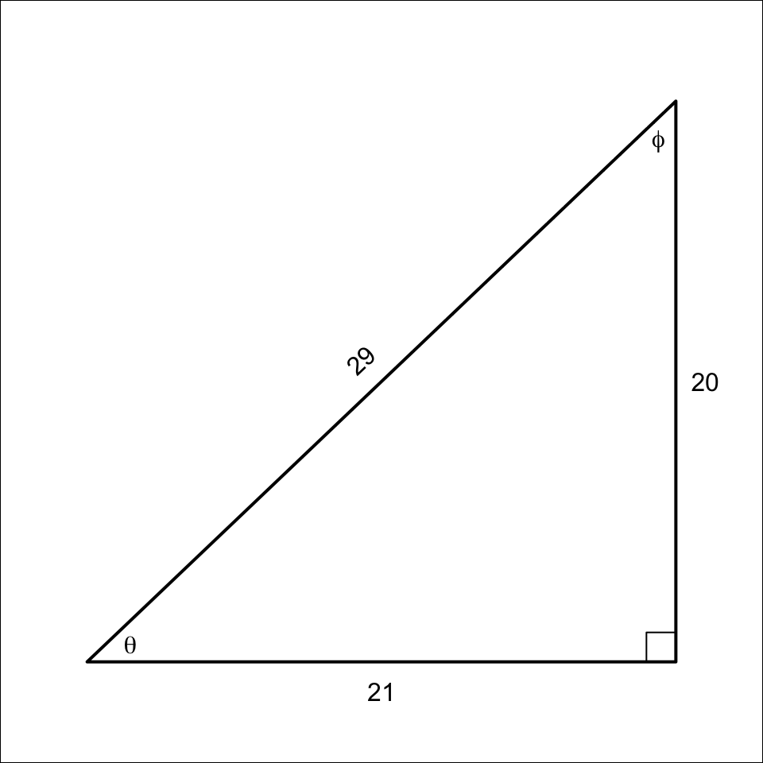

- $\sin(\theta)$ = ##ANSWER1##/##ANSWER2##
- $\cos(\theta)$ = ##ANSWER3##/##ANSWER4##
- $\tan(\theta)$ = ##ANSWER5##/##ANSWER6##
- $\csc(\theta)$ = ##ANSWER7##/##ANSWER8##
- $\sec(\theta)$ = ##ANSWER9##/##ANSWER10##
- $\cot(\theta)$ = ##ANSWER11##/##ANSWER12##
- $\sin(\phi)$ = ##ANSWER13##/##ANSWER14##
- $\cos(\phi)$ = ##ANSWER15##/##ANSWER16##
- $\tan(\phi)$ = ##ANSWER17##/##ANSWER18##
- $\csc(\phi)$ = ##ANSWER19##/##ANSWER20##
- $\sec(\phi)$ = ##ANSWER21##/##ANSWER22##
- $\cot(\phi)$ = ##ANSWER23##/##ANSWER24##

## Answerlist

- 20
- 21
- 29
- 20
- 21
- 29
- 20
- 21
- 29
- 20
- 21
- 29
- 20
- 21
- 29
- 20
- 21
- 29
- 20
- 21
- 29
- 20
- 21
- 29
- 20
- 21
- 29
- 20
- 21
- 29
- 20
- 21
- 29
- 20
- 21
- 29
- 20
- 21
- 29
- 20
- 21
- 29
- 20
- 21
- 29
- 20
- 21
- 29
- 20
- 21
- 29
- 20
- 21
- 29
- 20
- 21
- 29
- 20
- 21
- 29
- 20
- 21
- 29
- 20
- 21
- 29
- 20
- 21
- 29
- 20
- 21
- 29

# Solution

This is definitional. It is also exhaustive and tedious. Sorry?

- $\sin(\theta) = \frac{20}{29}$
- $\cos(\theta) = \frac{21}{29}$
- $\tan(\theta) = \frac{20}{21}$
- $\csc(\theta) = \frac{29}{20}$
- $\sec(\theta) = \frac{29}{21}$
- $\cot(\theta) = \frac{21}{20}$
- $\sin(\phi) = \frac{21}{29}$
- $\cos(\phi) = \frac{20}{29}$
- $\tan(\phi) = \frac{21}{20}$
- $\csc(\phi) = \frac{29}{21}$
- $\sec(\phi) = \frac{29}{20}$
- $\cot(\phi) = \frac{20}{21}$

# Meta-information

extype: cloze exclozetype: schoice|schoice|schoice|schoice|schoice|schoice|schoice|schoice|schoice|schoice|schoice|schoice|schoice|schoice|schoice|schoice|schoice|schoice|schoice|schoice|schoice|schoice|schoice|schoice exsolution: 100|001|010|001|100|010|001|100|001|010|010|100|010|001|100|001|010|100|001|010|001|100|100|010 exname: trig_ratios_from_sides